# Brownlows Bets

Jason briseno

2021-12-01

# 1 Introduction

At the first day of class there are 35 students in Math Statistics class and professor Brownlow always proposes this bet to his students “I will wager $2 to your bet of $1 that at least two people in today’s class have the same birthday. He tells me he has made that bet 637 times so far. Where do you think his profits are? Discuss this in a markdown document

```r
money=vector("numeric",0)
for(i in c(1:1000)){
  money[i]=(profit(35,2,637))
}
```

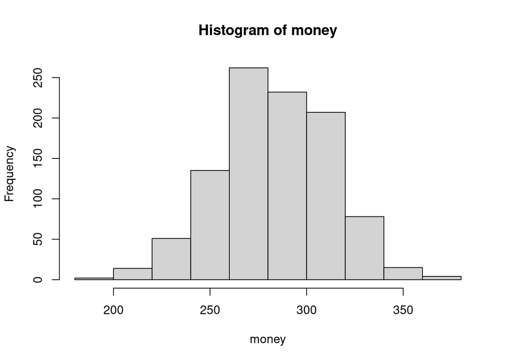

```r
hist(money)
```

Dr. Js profits are between 200 - 350.

```r
moneysorted=sort(money)
lci=moneysorted[26]
uci=moneysorted[974]
```

Report git commit structure: There are 3 questions and there should be at least 3 separate commits, at least one dealing with each of the 3 questions. 1. What are the fair odds for a bet on matching birthdays in a 35 person class. 2. For what size class is a 2:1 odds bet fair. 3. How much money would Brownlow be expected to end up with if the bets went as described.

## 1.1 Our strategy is to build a Function and the use it to answer the three questions.

The function will be given a class_size by number of students, odds, and Number_of_times brownlow made the bet. It will give you back how much Brownlows earnings were. We will use it to answer our three questions below. If you can, improve this function by giving default values to some of its inputs.

# 2 In the class and payoff as described If you highered 40 brownlow substitute teachers to do the same thing that Brownlow did then.

## 2.1 what is their average earnings?

```r
money=vector("numeric",0)
for(i in c(1:40)){
  money[i]=(profit(35,2,637))
}
```

```r
t.test(money)
```

```
##
##  One Sample t-test
##
## data:  money
## t = 67.143, df = 39, p-value < 2.2e-16
## alternative hypothesis: true mean is not equal to 0
## 95 percent confidence interval:
##  274.5473 291.6027
## sample estimates:
## mean of x
##   283.075
```

```r
print(sd(money))
```

```
## [1] 26.66448
```

## 2.2 the standard deviation and a 95% confidence interval for their earnings?

# 3 What are the fair odds? Use manipulation of odds in the function to tune Brownlows earnings to zero.

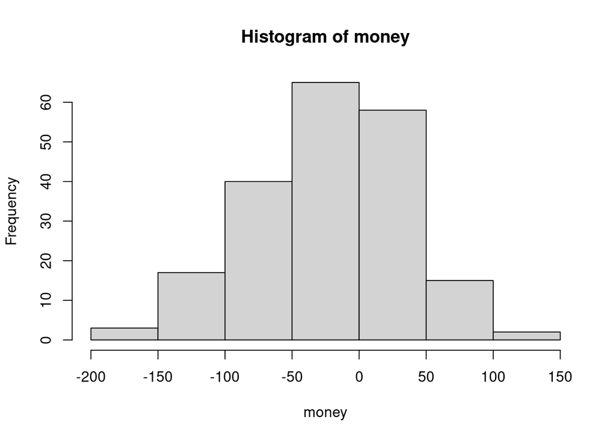

```r
money=vector("numeric",0)

for(i in c(1:200)){
  money[i]=(profit(35,4.5,637))
}
hist(money)
```

We chose random values for pay off odds until we got a histogram to center at 0. I started off with 1 which was too low, so we tried 5 which was closer to 0 but still to high. we went down to 4 which lead us to 4.5 which was the best pick. A manipulation of the odds variable to class size of 35 with an odds ratio of 4.5:1; that profits for Dr. J showed zero.

# 4 What size of class makes the 2:1 bet fair? Use manipulation of number of Students to tune Brownlows earnings to zero.

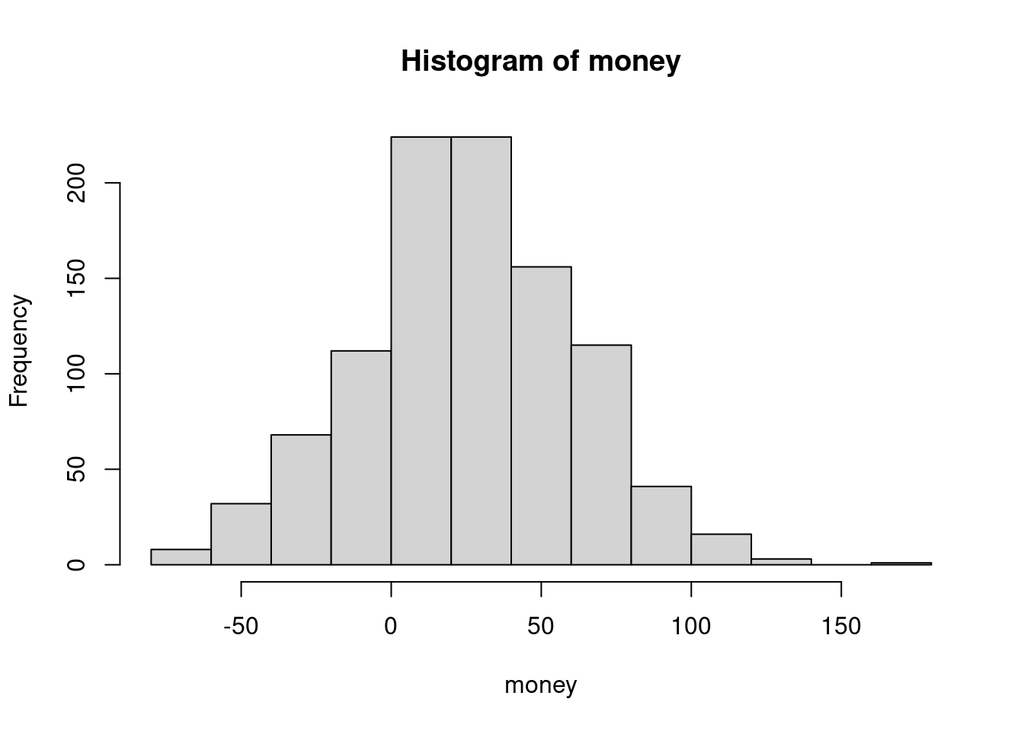

```r
money=vector("numeric",0)
for(i in c(1:1000)){
  money[i]=(profit(29,2,637))
}
hist(money)
```

We started with 35 which was too high, then we tried 37, then we tried 29 which was too high, then 28 which was too low, so we settled on 28 between 29 which we were pretty similar and both would be acceptable answers. So we went with 29 students with the bet being 2:1 which was close profit for Dr. J.

# 5 Discussion and Conclusion

We then changed the class size from 35 to either 28 or 29 students at 2:1 odds and we got the same results, Dr. J’s profits were closer to 0.